# BIS 621 - Logistic Regression Lecture

Josemari Feliciano  
Nov 4, 2019

### GLMs for Categorical Data

**A Modern Machine Learning Definition:** It is a classification algorithm used to assign observations to a discrete set of classes.

Types of logistic regression:

- Binary (e.g. Pass/Fail)
- Multiple (e.g. Cats, Dogs, Sheep)
- Ordinal (e.g. Low, Medium, High)

We will focus on **binary outcomes** today.

### Use of Logistic Regression in Medicine

**Question:** What is the binary outcome here?

[figure not shown]

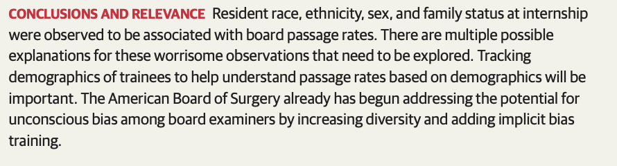

### Today's Case Study

**Data:** Contraceptive use data of 1607 currently married and fertile women interviewed in the Fiji Fertility Survey. *Source: Princeton's WWS 509*

**Data descriptors in the next page.**

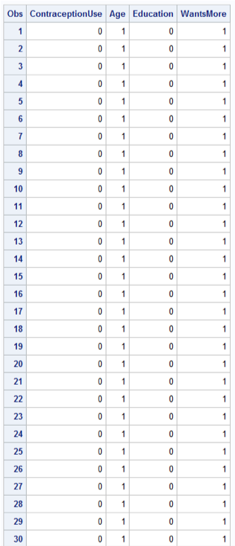

### Today's Case Study

**Data:** Contraceptive use data of 1607 currently married and fertile women interviewed in the Fiji Fertility Survey. *Source: Princeton's WWS 509*

### Today's Case Study

```
proc freq data = contraceptive;
table ContraceptiveUse Age Education WantsMore;
run;
```

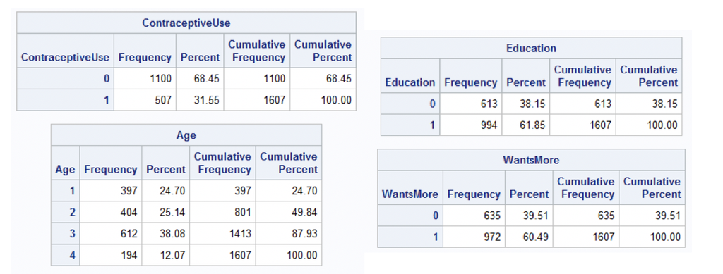

**Always good to check your data!**

### Multiple Logistic Regression

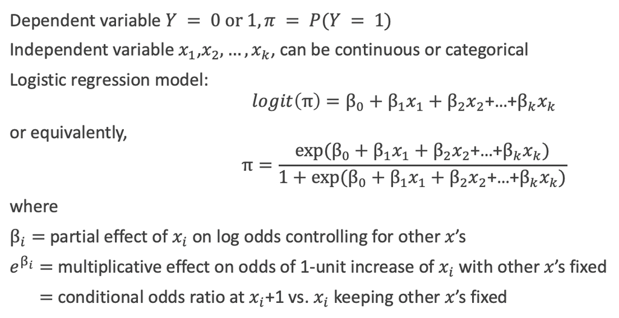

### Logistic in SAS

**SAS Code:** *Make sure to include descending so 1 is treated as binary outcome of interest*

```
proc logistic data = contraceptive descending;
class Age (ref = '1') Education (ref = '0') WantsMore (ref = '0');
model ContraceptiveUse = Age Education WantsMore;
run;
```

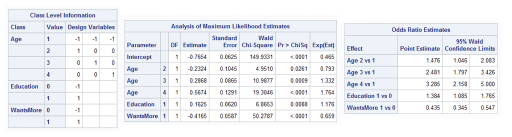

### Predictive Power

- **Sensitivity:** \( P(\hat{y} = 1| y =1) \)
- **Specificity:** \( P(\hat{y} = 0| y =0) \)
- **Receiver operating characteristics (ROC) curve:** a plot of sensitivity vs. (1-specificity)
- **Area under the curve (AUC):** area under the ROC curve

**Let us view an example in the next page.**

### Some of Work in Social Media Analytics

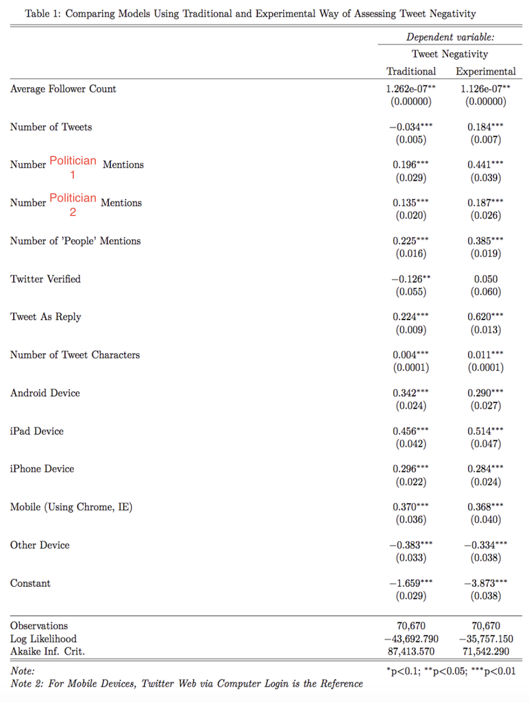

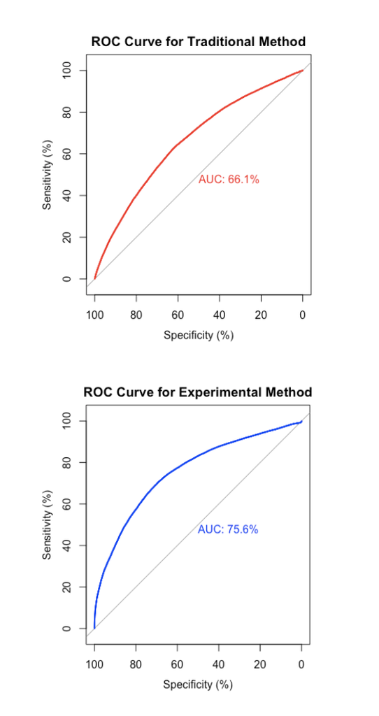

### ROC in SAS

**Add to your current code:** `outroc = ROCData`

```
proc logistic data = contraceptive descending;
model ContraceptiveUse = (your covariates) / outroc = ROCData;
run;
```

**What is the area under the curve?**

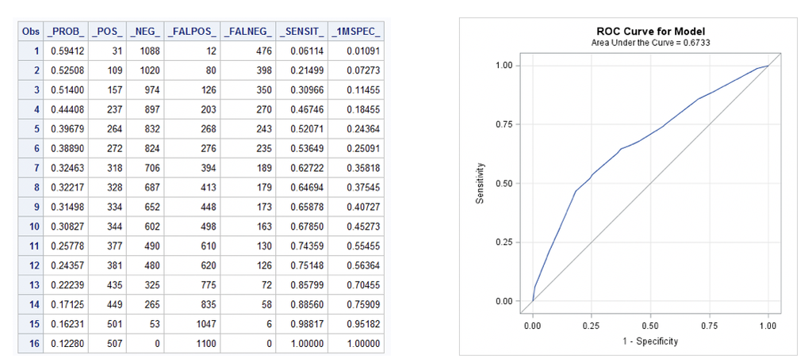

### Goodness of Fit

**Hosmer-Lemeshow test:** A statistical test for goodness of fit for logistic regression model. Assesses whether or not the observed event rates match expected event rates in subgroups of the model population. **Ho:** observed and expected proportions are the same across all doses (good fit). **Ha:** : observed and expected proportions differ significantly (lack of fit).

```
proc logistic data = contraceptive descending;
model ContraceptiveUse =  (your covariates) / lackfit; run;
```

### Goodness of Fit Output

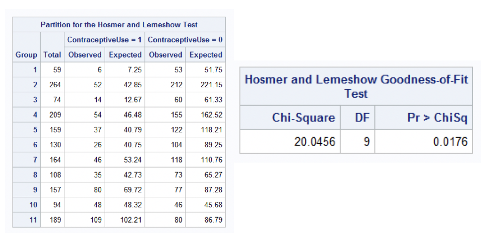

**Ho:** observed and expected proportions are the same across all doses (good fit). **Ha:** : observed and expected proportions differ significantly (lack of fit). **Conclusion:** We reject the null and conclude that the model does not accurately predict the probability of contraceptive use.

[output not shown]